# Working Memory Training Data

# Background

This simulated data is based off of training study run by David Moreau. In this study, he examined which of the following programs would be better for improving spatial memory:

1. Aerobic exercise (`aer`) – basically running on a treadmill.
2. Working memory training (`wm`) – memorizing locations while doing a distracting task on the computer.
3. Something he called Designed Sport Training (`combo`), meant to combine spatial memory with consistent exercise.

As shown in the diagram below, participants were tested on their spatial memory, then assigned to a program for a month. Afterward, their spatial memory was tested again.

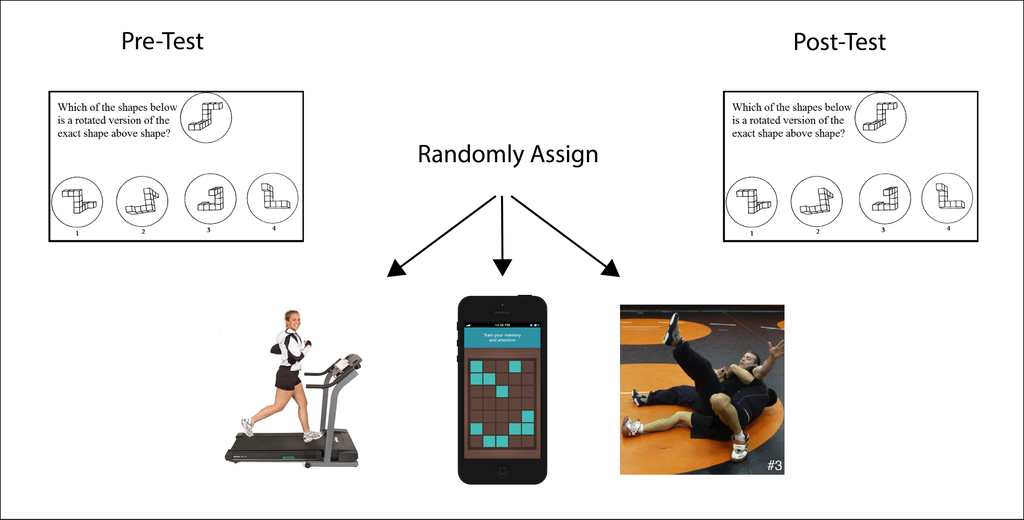

```r
wm_dat <- read.csv('training_long.csv')
```

The working memory data set has 60 rows and 5 columns. Below are the first 5 rows.

```r
head(wm_dat, 5)
```

```
  subject session wm_score cond time
1       1  wm_pre 27.75810   wm  pre
2       2  wm_pre 29.07929   wm  pre
3       3  wm_pre 36.23483   wm  pre
4       4  wm_pre 30.28203   wm  pre
5       5  wm_pre 30.51715   wm  pre
```

Note that the `session`, `cond`, and `time` columns are factors.

```r
str(wm_dat)
```

```
'data.frame':   60 obs. of  5 variables:
 $ subject : int  1 2 3 4 5 6 7 8 9 10 ...
 $ session : Factor w/ 6 levels "aer_post","aer_pre",..: 6 6 6 6 6 6 6 6 6 6 ...
 $ wm_score: num  27.8 29.1 36.2 30.3 30.5 ...
 $ cond    : Factor w/ 3 levels "aer","combo",..: 3 3 3 3 3 3 3 3 3 3 ...
 $ time    : Factor w/ 2 levels "post","pre": 2 2 2 2 2 2 2 2 2 2 ...
```

The levels of each factor are..

- **session**: aer_post, aer_pre, combo_post, combo_pre, wm_post, wm_pre
- **cond**: aer, combo, wm
- **time**: post, pre

# Questions

1. Using the `table` function, count the number of subjects in each combination of condition and time, using the `cond` and `time` columns.
2. Make a plot for each combination of condition and time (e.g. cond is “wm” and time is “pre”). There are 6 combinations total (3 conditions x 2 times). Be sure to give it useful labels.
3. Do a t-test of pre- vs post-test (i.e. `time`). What are the results? (We will ignore the fact that each person was tested at each time for now.)
4. Conduct a one-way ANOVA of condition for the pre-test group.
5. Conduct a two-way ANOVA of `cond`ition by `time`.

# Optional

1. Notice that each subject has a pre- and post- test score. How would you make a scatterplot of each person’s pre-test score against their post-test score?